# Reproducible Research: Peer Assessment 1

## Loading and preprocessing the data

### Initializations

Make some initial environmental settings for the script. This makes sure we have needed libraries loaded and key script variables set. Specifically, we expect the data to be in our working directory. The same directory from which our R script is running. That needs to be set. When running this script on your computer, set the *working_dir* variable accordingly, so that you can reproduce the output.

```r
# NOTE:
# message=FALSE was used to suppress the library loading messages. These
# are not useful for our analysis output.

# libraries
library(dplyr)
library(lubridate)

# set working_dir variable
working_dir <- "~/Documents/courses/repdata/RepData_PeerAssessment1"

# set working directory
setwd(working_dir)
```

### Load the data

Read data file *activity.csv* into data frame activity.

```r
# read the data
activity <- read.csv("activity.csv")
```

## What is mean total number of steps taken per day?

```r
# get dailySteps by day
dailySteps <- aggregate(steps ~ date, activity, sum)
meanSteps <- as.integer(mean(dailySteps$steps))
medianSteps <- as.integer(median(dailySteps$steps))

# get interval steps by day
dailyAvg <- aggregate(steps ~ interval, activity, mean)

# calculate max interval across all days
max_interval <- dailyAvg[which(dailyAvg$steps == max(dailyAvg$steps)),]$interval
```

Below is the historgam of the total number of step taken. The **mean** and **median** of total number of steps taken per day are 10766 and 10765 respectively.

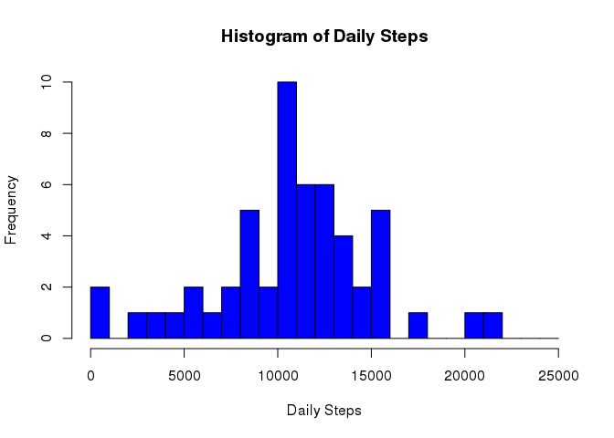

```r
hist(dailySteps$steps,
     breaks=seq(0,25000,1000),
     col="BLUE",
     main="Histogram of Daily Steps",
     xlab="Daily Steps")
```

## What is the average daily activity pattern?

Below is a time series plot of the 5-minute intervals and the average number of steps taken, averaged across all days.

The interval which contains the maximum average, across all days in the dataset, is 835

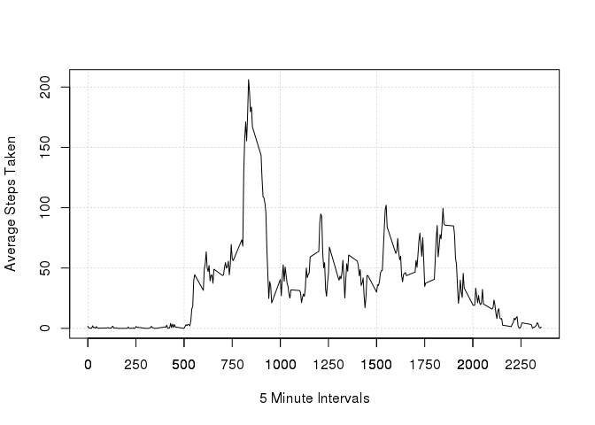

```r
plot(dailyAvg$interval,
     dailyAvg$steps,
     type = "l",
     xlab = "5 Minute Intervals",
     ylab = "Average Steps Taken",
     panel.first = grid()
)
axis(side=1, at = seq(0,2500,250))
```

## Imputing missing values

To impute missing values the average steps per interval were used. For example, if there is a missing value for interval 10 on any day and the average for interval 10 is 2.4, then the missing values for interval 10 are set to 2.4.

```r
# get count of the total number NA values
total_na <- length(activity[which(is.na(activity$steps)),]$steps)

# replace missing values with corresponding mean of the interval
missing <- which(is.na(activity$steps))
i_mean <- aggregate(steps ~ interval, activity, mean)
for (r in missing) {
  activity$steps[r] <- i_mean$steps[i_mean$interval == activity$interval[r]]
}

# get dailySteps by day
dailySteps <- aggregate(steps ~ date, activity, sum)
meanSteps <- as.integer(mean(dailySteps$steps))
medianSteps <- as.integer(median(dailySteps$steps))

# get interval steps by day
dailyAvg <- aggregate(steps ~ interval, activity, mean)
```

Total number of missing values is 2304

Below is the historgam of the total number of step taken using the imputed data. The **mean** and **median** of total number of steps taken per day are 10766 and 10766 respectively.

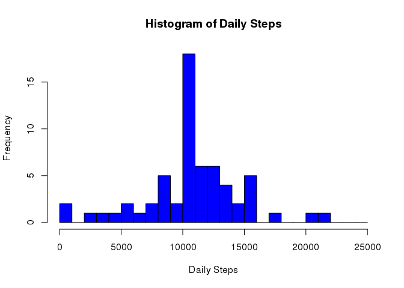

```r
hist(dailySteps$steps,
     breaks=seq(0,25000,1000),
     col="BLUE",
     main="Histogram of Daily Steps",
     xlab="Daily Steps")
```

## Are there differences in activity patterns between weekdays and weekends?

Using the imputed activity dataframe, we add colum *dayofweek* so we can break out the data by weekend and weekday. Similar calculations as those for the first time series plot are done on the weekend and weekday data and plotted together.

The graphs below indicate that there is more activity on the weekend between the intervals of 1000 to 2100 than during the weekdays.

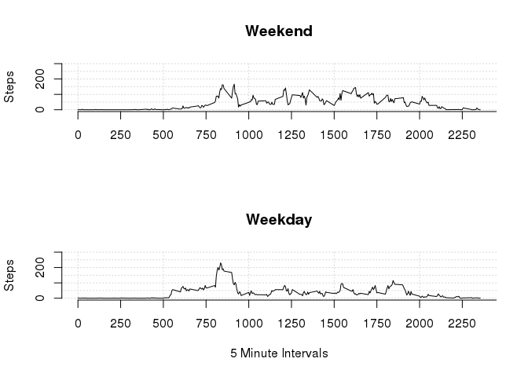

```r
# add new column dayofweek; populate with the day name (Sun - Sat)
activity$dayofweek = wday(ymd(activity$date),label=TRUE)

weekday <- activity %>%
            filter(dayofweek %in% c("Mon","Tues","Wed","Thurs","Fri"))
weekday <- aggregate(steps ~ interval, weekday, mean)

weekend <- activity %>%
            filter(dayofweek %in% c("Sun","Sat"))
weekend <- aggregate(steps ~ interval, weekend, mean)


par(mfrow=c(2,1))
plot(weekend$interval,
     weekend$steps,
     ylim = c(0,300),
     type = "l",
     xlab = "",
     ylab = "Steps",
     main = "Weekend",
     axes = FALSE,
     panel.first = grid()
)
axis(side=1, at = seq(0,2500,250))
axis(side=2, at = seq(0,300,100))

plot(weekday$interval,
     weekday$steps,
     ylim = c(0,300),
     type = "l",
     xlab = "5 Minute Intervals",
     ylab = "Steps",
     main = "Weekday",
     axes = FALSE,
     panel.first = grid()
)
axis(side=1, at = seq(0,2500,250))
axis(side=2, at = seq(0,300,100))
```